# Intro to R

This document is a product of the livecode that I did during this [tech talk](https://www.youtube.com/watch?v=L2rCJFX_QA8). Checkout the talk for more details and explanation.

It’s good to start by loading any libraries (packages) you know you will be using.

```r
library(ggplot2)
library(plyr)
library(scales)
library(gridExtra)
```

Next, we need some data!

```r
complaints = read.csv("housing_complaints.csv")
str(complaints)
```

```
'data.frame':   993137 obs. of  15 variables:
 $ ComplaintID   : int  6960137 6960832 6946867 6966946 6956574 6959035 6924412 6944891 6961276 6959795 ...
 $ BuildingID    : int  3418 3512 5318 5608 17896 19899 25304 32017 37344 41208 ...
 $ BoroughID     : int  1 1 1 1 1 1 1 1 1 1 ...
 $ Borough       : Factor w/ 5 levels "BRONX","BROOKLYN",..: 3 3 3 3 3 3 3 3 3 3 ...
 $ HouseNumber   : Factor w/ 14870 levels ".537","1","1-12",..: 5126 6210 12961 3929 6353 9855 10636 8768 5455 8120 ...
 $ StreetName    : Factor w/ 4736 levels "1 AVENUE","1 PLACE",..: 691 691 37 748 2026 1809 3025 4515 4366 4408 ...
 $ Zip           : num  10026 10030 10019 10031 10128 ...
 $ Block         : int  1904 1918 1083 2073 1533 1710 1947 753 1873 2041 ...
 $ Lot           : int  4 4 1 29 32 36 47 10 24 40 ...
 $ Apartment     : Factor w/ 8531 levels "","1","1.6E+5",..: 392 2624 3306 3557 1058 2668 2891 1678 7721 3753 ...
 $ CommunityBoard: int  10 10 4 9 8 11 10 4 7 10 ...
 $ ReceivedDate  : Factor w/ 1622 levels "01/01/2009","01/01/2014",..: 832 835 772 861 812 822 671 765 835 832 ...
 $ StatusID      : int  2 2 2 2 2 2 2 2 2 2 ...
 $ Status        : Factor w/ 2 levels "CLOSE","OPEN": 1 1 1 1 1 1 1 1 1 1 ...
 $ StatusDate    : Factor w/ 1129 levels "01/01/2015","01/01/2017",..: 591 538 541 566 528 531 511 570 535 550 ...
```

This provides a nice summary of our data.

```r
summary(complaints)
```

```
  ComplaintID        BuildingID       BoroughID              Borough        HouseNumber
 Min.   :      0   Min.   :     1   Min.   :1.000   BRONX        :308041   1025   :  4735
 1st Qu.:7284404   1st Qu.: 55124   1st Qu.:2.000   BROOKLYN     :316918   34     :  4630
 Median :7709734   Median :135072   Median :2.000   MANHATTAN    :225667   89-21  :  3383
 Mean   :7706871   Mean   :266267   Mean   :2.392   QUEENS       :129104   30     :  3175
 3rd Qu.:8108853   3rd Qu.:373864   3rd Qu.:3.000   STATEN ISLAND: 13407   109    :  2691
 Max.   :8477149   Max.   :976293   Max.   :5.000                          125    :  2225
                                                                           (Other):972298
              StreetName          Zip            Block            Lot           Apartment      CommunityBoard
 GRAND CONCOURSE   : 15773   Min.   : 2014   Min.   :    0   Min.   :   0.0   BLDG   :212501   Min.   : 0.00
 BROADWAY          : 12839   1st Qu.:10451   1st Qu.: 1841   1st Qu.:  14.0   2      : 29154   1st Qu.: 4.00
 OCEAN AVENUE      :  8420   Median :10468   Median : 2872   Median :  34.0   1      : 26469   Median : 8.00
 MORRIS AVENUE     :  7200   Mean   :10723   Mean   : 3479   Mean   : 228.3   1A     : 16528   Mean   : 8.04
 BOYNTON AVENUE    :  7051   3rd Qu.:11222   3rd Qu.: 4547   3rd Qu.:  58.0   3      : 15485   3rd Qu.:12.00
 ST NICHOLAS AVENUE:  6522   Max.   :11697   Max.   :16350   Max.   :9100.0   (Other):692842   Max.   :82.00
 (Other)           :935332   NA's   :504                                      NA's   :   158
     ReceivedDate       StatusID       Status            StatusDate
 02/14/2016:  6146   Min.   :1.000   CLOSE:972528   02/18/2016:  4415
 01/08/2015:  5860   1st Qu.:2.000   OPEN : 20609   11/21/2014:  3393
 02/16/2015:  5287   Median :2.000                  02/19/2015:  3317
 01/07/2015:  4234   Mean   :1.979                  02/20/2015:  3313
 02/15/2016:  4188   3rd Qu.:2.000                  02/26/2015:  3295
 12/16/2016:  4082   Max.   :2.000                  01/13/2015:  3219
 (Other)   :963340                                  (Other)   :972185
```

Here comes our first ggplot!

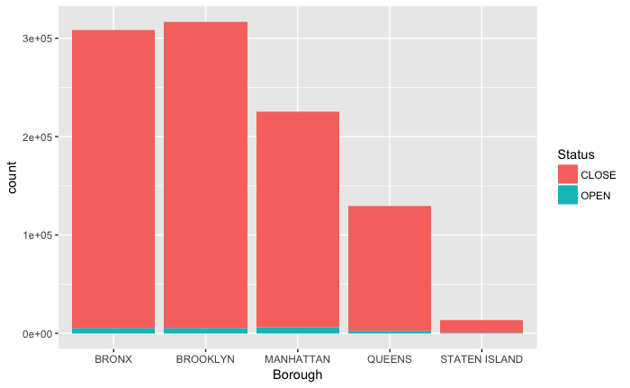

```r
ggplot(complaints, aes(x=Borough, fill=Status)) +
  geom_bar()
```

R also makes data transformation easy: here the ReceivedDate and StatusDate columns are turned into ‘Date’ types rather than factors, and a new column is created by substracting those two.

```r
complaints$ReceivedDate <- as.Date(complaints$ReceivedDate, format = "%m/%d/%Y")
complaints$StatusDate <- as.Date(complaints$StatusDate, format = "%m/%d/%Y" )
complaints$daysToResolve <- complaints$StatusDate - complaints$ReceivedDate
```

A jitterplot is a great take on a scatterplot when you know that multiple points will be showing up in the same spot. By ‘jittering’ (moving the points a little bit randomly) you can get a better idea of where many points are showing up. Making the points smaller and adding transparency have the same effect.

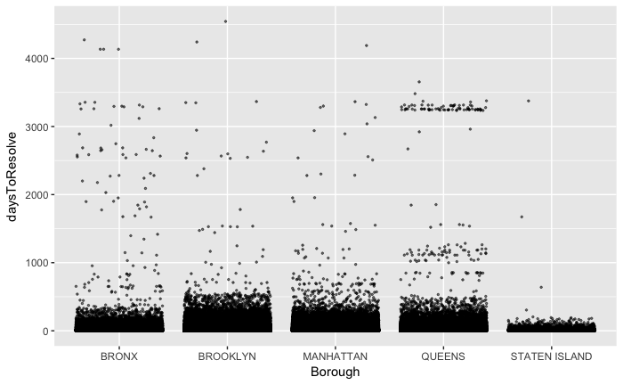

```r
ggplot(complaints, aes(x=Borough, y=daysToResolve)) +
  geom_jitter(size = 0.5, alpha = 0.5)
```

R also performs statistical operations (including ones more complex than these)

```r
mean(complaints$daysToResolve)
```

```
Time difference of 13.39853 days
```

```r
median(complaints$daysToResolve)
```

```
Time difference of 5 days
```

Even though we used a jitterplot above, the vast majority of the complaints were resolved in less than 15 days – a box plot shows this more accurately than a jitterplot.

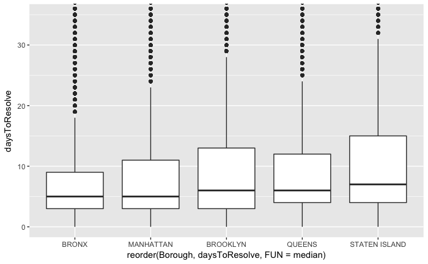

```r
ggplot(complaints, aes(x = reorder(Borough, daysToResolve, FUN = median), y = daysToResolve)) +
  geom_boxplot() +
  coord_cartesian(ylim = c(0, 35))
```

In the code block below I load two more datasets and use the plyr package to join them. Because it’s an inner join, only rows with matching development name, borough, account name, location, and revenue month are included.

```r
# Loading in two new datasets
electric <- read.csv("Electric_Consumption_And_Cost__2010_-__2016_.csv")
water <- read.csv("Water_Consumption_And_Cost__2013_-_2016_.csv")
# Renaming duplicate columns
water$Water.Charges <- water$Current.Charges
electric$Electric.Charges <- electric$Current.Charges
# Selecting only some of the columns
water <- subset(water, select = c(Development.Name, Borough, Account.Name, Location, Revenue.Month, Water.Charges, Consumption..HCF.))
electric <- subset(electric, select = c(Development.Name, Borough, Account.Name, Location, Revenue.Month, Electric.Charges, Consumption..KW.))
# Using an inner join to combine tables so that only rows with matching development name, borough, account name, location, and revenue month are included
bills <- join(electric, water, by=c('Development.Name', 'Borough', 'Account.Name', 'Location', 'Revenue.Month'), type = 'inner')
# Recasting the date and currency data
bills$Revenue.Month <- as.Date(bills$Revenue.Month, format = "%m/%d/%Y")
bills$Electric.Charges <- gsub("(\\$|,)","", bills$Electric.Charges)
bills$Electric.Charges <- as.numeric(bills$Electric.Charges)
bills$Water.Charges <- gsub("(\\$|,)","", bills$Water.Charges)
bills$Water.Charges <- as.numeric(bills$Water.Charges)
```

Here I am interested in seeing the relationship between electric charges and water charges. Adding a color to the jitter plot adds a 3rd variable – the month.

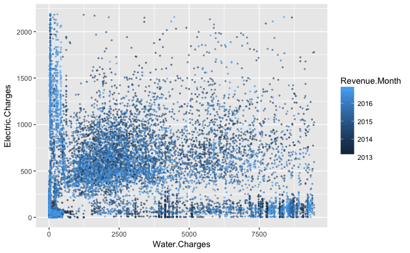

```r
ggplot(bills, aes(x = Water.Charges, y = Electric.Charges)) +
  geom_jitter(size = 0.5, alpha = 0.5, aes(color = Revenue.Month)) +
  xlim(0, quantile(bills$Water.Charges, 0.9)) +
  ylim(0, quantile(bills$Electric.Charges, 0.9))
```

There was too much information going on in the plot above, so I chose to use a facet-wrap to separate out the jitterplots month by month.

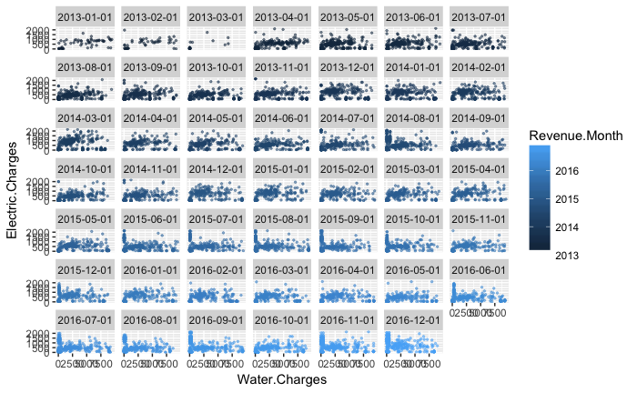

```r
ggplot(bills, aes(x = Water.Charges, y = Electric.Charges)) +
  geom_jitter(size = 0.5, alpha = 0.5, aes(color = Revenue.Month)) +
  xlim(0, quantile(bills$Water.Charges, 0.9)) +
  ylim(0, quantile(bills$Electric.Charges, 0.9)) +
  facet_wrap(~Revenue.Month)
```

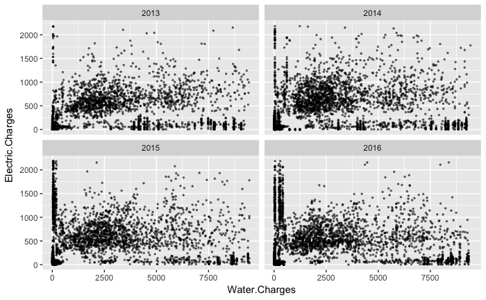

```r
bills$Year <- as.numeric(format(bills$Revenue.Month,'%Y'))
ggplot(bills, aes(x = Water.Charges, y = Electric.Charges)) +
  geom_jitter(size = 0.5, alpha = 0.5) +
  xlim(0, quantile(bills$Water.Charges, 0.9)) +
  ylim(0, quantile(bills$Electric.Charges, 0.9)) +
  facet_wrap(~Year)
```

Just for kicks, this last graph shows how you can wrap (facet-wrap, that is) four variables into a plot. Water charges on the x-axis, electric charges on the y-axis, revenue month in color, and borough through facets.

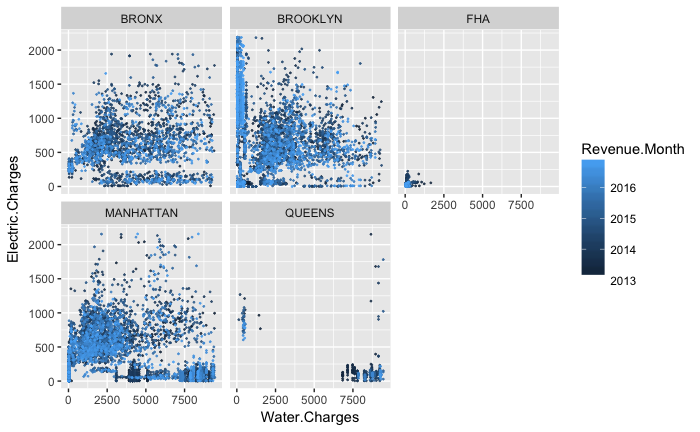

```r
ggplot(bills, aes(x = Water.Charges, y = Electric.Charges)) +
  geom_jitter(size = 0.25, alpha = 0.75, aes(color = Revenue.Month)) +
  xlim(0, quantile(bills$Water.Charges, 0.9)) +
  ylim(0, quantile(bills$Electric.Charges, 0.9)) +
  facet_wrap(~Borough)
```